# Gaussian Graphical Model Simulation

Seungbongjung 2017-15716

2021 02 08

In this report, I implemented Graphical Lasso(denoted by ‘GL’) in both frequentist context and bayesian context. I simulated GL with four models and applied GL to real data, which will be described in the below, in order to compare performance between frequentist context and bayesian context. Let $\sum=(\sigma_{ij})$ be covariance matrix and $\Omega=(\omega_{ij})$ be its corresponding precision matrix. Four models used in the simulation are given as following:

Model1: AR(1) model, $\sigma_{ij}=0.7^{|i-j|}$

Model2: AR(2) model, $\omega_{ii}=1, \omega_{i-1,i}=\omega_{i,i-1}=0.5, \omega_{i-2,i}=\omega_{i,i-2}=0.25$

Model3: Star model, $\omega_{ii}=1, \omega_{1,i}=\omega_{i,1}=0.1$, and $\omega_{ij}=0$ otherwise.

Model4: Circle model, $\omega_{ii}=2,\omega_{i-1,i}=\omega_{i,i-1}=1,\omega_{1,p}=\omega_{p,1}=0.9$

```r
library(mvtnorm)
library(glasso)
library(tidyverse)
library(ggm)
library(igraph)
library(gridExtra)
library(sparsebn)

p1=30; p2=50; p3=100;
n1=100; n2=200
lambda=seq(from=0,to=1,length=51)
lambda=lambda[-1]
```

Following functions implement GL and measure the performance of it. Function edge_count counts the edge between $i$th node and $j$th node.($i<j$) If $|\omega_{ij}|<0.1^3$, we may say there is no edge between $i$th node and $j$ node.

Also, function graphical_lasso implements GL in frequentist context. With true covariance matrix $\sum$ given, it samples $X_1, X_2,\dots,X_n$ from $MVN(0,\sum)$ and caculates sample covriance matrix $S$. Then if penalty parameter $\rho$ is given, it gives estimator $\hat{\Omega}$ using GL. Objective function is given as following :

$\hat{\Omega}=argmin_{\Omega>0}(tr(S\Omega)-\log\det\Omega+\rho\sum_{i\neq j}\Omega_{ij})$.

Function bayesian_GL implements GL in bayesian context. Let $\mathbf{\Gamma}=(\gamma_{ij})$ be model indicator. We consider regular models only. Here regular model refers to the model whose model indicator and estimated model indicator coincide, otherwise non-regular model. Regularity is necessary for validity of Laplace approximation. With $\text{n}\times\text{p}$ data $X^{(n)}$ given, we have approximated posterior $\mathbf{p(\Gamma|X^{(n)})}$ of $\mathbf{\Gamma}$ as following:

$\mathbf{p(\Gamma|X^{(n)})}\propto \mathbf{C_{\Gamma}}\exp(-n\mathbf{h_{\Gamma}(\Omega_{\Gamma}^*)}/2)(4\pi/n)^{(p+\# \mathbf{\Gamma})/2}[\det(\mathbf{H_{\Omega_{\Gamma}^*}})]^{-1/2}$ \

where $\mathbf{C_{\Gamma}}=(2\pi)^{-np/2}q^{\# \mathbf{\Gamma}}(1-q)^{\binom{p}{2}-\#\mathbf{\Gamma}}(\frac{n\lambda}{2})^{p+\# \mathbf{\Gamma}}\text{I}(\# \mathbf{\Gamma}\leq \bar{r})$, $\displaystyle \mathbf{h_{\Gamma}}=-\log \det(\mathbf{\Omega_{\Gamma}})+\text{tr}(\hat{\mathbf{\Sigma}}\mathbf{\Omega_{\Gamma}})+2\lambda \sum_{\gamma_{ij}=1}|\omega_{\mathbf{\Gamma},ij}|+\lambda \sum_{i=1}^p \omega_{\mathbf{\Gamma},ii}$ and $\mathbf{\Omega_{\Gamma}^*}$ refers to estimated precision matrix corresponding to the model $\mathbf{\Gamma}$ through frequentist GL. Further, matrix $\mathbf{H_B}=((\mathbf{h_B}\{(i,j),(l,m)\}))$ is defined by $\mathbf{h_B}\{(i,j),(l,m)\}=\text{tr}(\mathbf{B}^{-1}\mathbf{E}_{(i,j)}\mathbf{B}^{-1}\mathbf{E}_{(l,m)})$, where $\mathbf{E}_{(i,j)}$ is matrix of appropriate size with 1 on (i,j), (j,i) entries and 0 elsewhere. Note $\mathbf{\Omega_{\Gamma}}=((\omega_{\mathbf{\Gamma},ij}))$ denotes the precision matrix corresponding to the model $\mathbf{\Gamma}$ and $\mathbf{\Omega_{\Gamma}}^*$ is the graphical lasso solution of the model $\mathbf{\Gamma}$.

We use Metropolis-Hastings algorithm to obtain MCMC samples of $\mathbf{\Gamma}$. To do so, we suggest symmetric proposal distribution $q(G'|G)$. Let $\mathbf{\Gamma},\mathbf{\Gamma}'$ be model indicator of $G=(V,E),G'=(V,E')$ respectively. We sample $(i,j)$ from $\text{V}\times \text{V}$. If $\gamma(i,j)=0$, we set $\gamma'(i,j)=1$, else $\gamma'(i,j)=0$. Simply let $\gamma'(-i,-j)=\gamma(-i,-j)$ for other pairs. $q$ is indeed symmetric proposal distribution as we sample $G'$ uniformly from the graphs that differ from $G$ in one position, so we have equal probability to set $\gamma'(i,j)=1$ or $\gamma'(i,j)=0$. With this proposal distribution, we have Metrpolis-Hastings algorithm as following :

Algorithm

0. Initial model indicator: $\mathbf{\Gamma}^{(0)}$, Given data : $X^{(n)}$

For $i=0,1,\dots,n$

1. $\mathbf{\Gamma}^{\text{temp}}\sim q(G^{\text{temp}}|G^{(0)})$
2. Check regularity of $\mathbf{\Gamma}^{\text{temp}}$.
3. If model $\mathbf{\Gamma}^{\text{temp}}$ is regular, $\mathbf{\Gamma}^{\text{cand}}=\mathbf{\Gamma}^{\text{temp}}$. Else, repeat 1~2.
4. $\alpha_i=\min\{1,\frac{\mathbf{p}(\mathbf{\Gamma}^{\text{cand}}|X^{(n)})}{\mathbf{p}(\mathbf{\Gamma}^{(i)}|X^{(n)})} \}$
5. $U_i\sim U(0,1)$
6. If $U_i\leq \alpha_i$, $\mathbf{\Gamma}^{(i+1)}=\mathbf{\Gamma}^{\text{cand}}$. Else, $\mathbf{\Gamma}^{(i+1)}=\mathbf{\Gamma}^{(i)}$.

We use Median Probability Model(denoted by ‘MPP’) to select final model $\mathbf{\Gamma}$ from MCMC samples. Note that we set model size restriction $\bar{r}$ by the model size from frequentist GL.

Finally, function accuracy measures how $\Omega$ is accurate in terms of edge for frequentist GL. The function graphical_lasso repeats the frequentist GL for $k$ times and measure the performance for each time. We average each measure over these $k$ models and use this value as final performance measure.

Function accuracy_bayes measures how $\Omega$ is accurate in terms of edge for bayesian_GL. The function bayesian_GL repeats the bayesian GL for $k$ times and so we have $k$ samples of $\mathbf{\Gamma}$. We measure the peformance for each sample by comparing $\mathbf{\Gamma}^{(i)}$ and $\mathbf{\Gamma}_0$, where $\mathbf{\Gamma}_0$ denotes the true model indicator. Again, we average each measure over these $k$ models and use this value as final performance measure.

The measures used in the simulation are SE(sensitivity), SP(specificity), MCC(Matthews Correlation Coefficient)and FPR(False Positive Rate). They are defined as following:

TP: True Positive, edges are present which are also present in the true model.

TN: True Negative, edges are absent which are also absent in the true model.

FP: False Positive, edges are present which are absent in the true model.

FN: False Negative, edges are absent which are prsent in the true model.

$SP=\frac{TN}{TN+FP}, SE=\frac{TP}{TP+FN}, FPR=1-SP, MCC=\frac{TP\cdot TN-FP\cdot FN}{\sqrt{(TP+FP)(TP+FN)(TN+FP)(TN+FN)}}$

```r
edge_count=function(m){
  temp=m[upper.tri(m)]
  temp=abs(temp)>0.1^3
  return(temp)
}

#implements frequentist graphical lasso
graphical_lasso=function(n,p,sigma,rho,iter,seed){
  edge_temp=edge_count(solve(sigma))
  result=list(tp=numeric(iter),tn=numeric(iter),fp=numeric(iter),fn=numeric(iter))

  for(i in 1:iter){
    samp=rmvnorm(n,mean=rep(0,p),sigma)
    samp_var=t(samp)%*%samp/n
    estimated_var=glasso(s=samp_var,rho)
    estimated_var=estimated_var$wi
    estimated_var_temp=edge_count(estimated_var)

    result[[1]][i]=length(intersect(which(estimated_var_temp==1),which(edge_temp==1)))
    result[[2]][i]=length(intersect(which(estimated_var_temp==0),which(edge_temp==0)))
    result[[3]][i]=length(intersect(which(estimated_var_temp==1),which(edge_temp==0)))
    result[[4]][i]=length(intersect(which(estimated_var_temp==0),which(edge_temp==1)))
  }
  return(result)
}

accuracy=function(data){
  tp=data[[1]]; tn=data[[2]]; fp=data[[3]]; fn=data[[4]]
  sp=tn/(tn+fp)
  se=tp/(tp+fn)
  mcc=(tp*tn-fp*fn)/sqrt((tp+fp)*(tp+fn)*(tn+fp)*(tn+fn))
  fpr=1-sp
  return(list(sp,se,mcc,fpr))
}

#implements bayesian graphical lasso

c_gamma=function(n,p,gamma1,gamma2,lambda,q,r){
  gamma1=sum(gamma1)
  gamma2=sum(gamma2)
  gamma=gamma1-gamma2
  rho=lambda*n
  result=q^gamma*(1-q)^(-gamma)*(rho/2)^(gamma)*as.numeric(gamma1<=r)
  return(result)
}

h_gamma=function(s,prec,lambda,n){
  rho=lambda*n
  temp=prec[upper.tri(prec)]
  temp=abs(temp[which(abs(temp)>0.1^3)])
  result=-log(det(prec))+sum(diag(s%*%prec))+rho/n*sum(diag(prec))+2*rho/n*sum(temp)
  return(result)
}

H=function(mat,p){
  mat_inv=solve(mat)
  ind=matrix(rep(1:p,2),ncol=2)
  temp=mat
  temp[lower.tri(temp,diag=TRUE)]=0
  mat_ind=which(abs(temp)>0.1^3,arr.ind=TRUE)
  gamma_ind=rbind(ind,mat_ind)
  n=nrow(gamma_ind)
  result=matrix(rep(0,n^2),ncol=n)
  for(a in 1:n){
    for(b in a:n){
      i=gamma_ind[a,][1]; j=gamma_ind[a,][2]; l=gamma_ind[b,][1]; m=gamma_ind[b,][2]
      if((i!=j) & (l!=m)){
        result[a,b]=2*(mat_inv[i,l]*mat_inv[j,m]+mat_inv[i,m]*mat_inv[j,l])
      }
      if((i==j) & (l!=m)){
        result[a,b]=2*mat_inv[i,l]*mat_inv[i,m]
      }
      if((i==j) & (l==m)){
        result[a,b]=(mat_inv[i,l])^2
      }
    }
  }
  result[lower.tri(result)]=t(result)[lower.tri(result)]
  return(result)
}

posterior_ratio=function(n,p,s,prec1,prec2,q,lambda,gamma1,gamma2,r){
 C=c_gamma(n,p,gamma1,gamma2,lambda,q,r)
 h=h_gamma(s,prec1,lambda,n)-h_gamma(s,prec2,lambda,n)
 ind=sum(gamma1)-sum(gamma2)
 e1=eigen(H(prec2,p))$values; e2=eigen(H(prec1,p))$values
 e1=prod(sqrt(abs(e1))); e2=prod(sqrt(abs(e2)))
 H=e1/e2
 result=C*(4*pi/n)^(ind/2)*H*exp(-n*h/2)
 return(result)
}

q=function(gamma,p){
  m=choose(p,2)
  samp=sample(1:m,1)
  result=gamma
  if(gamma[samp]==1){
    result[samp]=0
  }
  if(gamma[samp]==0){
    result[samp]=1
  }
  return(result)
}

bayesian_GL=function(n,p,sigma,q,lambda,seed,iter1,iter2,burnin){
  set.seed(seed)
  m1=array(NA,dim=c(1,choose(p,2),iter1))
  E_p=array(NA,dim=c(1,2,0))
  for(k in 2:p){
    for(l in 1:(k-1)){
      E_p=array(c(E_p,c(l,k)),dim=dim(E_p)+c(0,0,1))
    }
  }
  #Indicator of edge
  E_p=matrix(E_p,ncol=2,byrow=TRUE)

  for(i in 1:iter1){
  #iter1 refers to number of replications
   samp=rmvnorm(n,mean=rep(0,p),sigma=sigma)
   s=1/n*t(samp)%*%samp
   prec=glasso(s,rho=lambda)$wi
   gamma=edge_count(prec)
   r=sum(gamma)
    gamma_int=gamma
   for(j in 1:5){
     gamma_int=q(gamma_int,p)
   }
   gamma=gamma_int
   m2=array(NA,dim=c(1,choose(p,2),iter2))
   for(j in 1:iter2){
     #iter2 refers to number of MCMC samples including burn-in
     #Sampling MCMC samples from Metropolis-Hastings algorithm
     gamma_temp=q(gamma,p)
     prec_temp=glasso(s,rho=lambda,zero=E_p[as.logical(1-gamma_temp),])$wi
     prec_gamma=edge_count(prec_temp)
     #Checking validity of Laplace approximation(i.e. verifying regular model)
     while(all(prec_gamma==gamma_temp)==0){
        gamma_temp=q(gamma,p)
        prec_temp=glasso(s,rho=lambda,zero=E_p[as.logical(1-gamma_temp),])$wi
        prec_gamma=edge_count(prec_temp)
      }
     u=runif(1,0,1)
     alpha=posterior_ratio(n,p,s,prec_temp,prec,q,lambda,gamma_temp,gamma,r)
     alpha=min(c(1,alpha))
     if(u<=alpha){
       gamma=gamma_temp
       prec=prec_temp
     }
     m2[,,j]=gamma
     if(j%%100 == 0){
     print(paste0("Replication : ",i," Iteration :",j))
     }
   }
   z=iter2-burnin
   m2_temp=m2[,,(burnin+1):iter2]
   m_temp=rowSums(m2_temp,dims=1)
   m_temp=as.vector(m_temp)/z
   m_temp=as.numeric(m_temp>=0.5)
   m1[,,i]=m_temp
  }
  return(m1)
}

accuracy_GL=function(estimated_gamma,true_gamma,k){
  #k denotes the number of samples
 performance=list(tp=numeric(k),tn=numeric(k),fp=numeric(k),fn=numeric(k))
 for(i in 1:k){
   estimate=as.vector(estimated_gamma[i,])
   performance[[1]][i]=length(intersect(which(estimate==1),which(true_gamma==1)))
   performance[[2]][i]=length(intersect(which(estimate==0),which(true_gamma==0)))
   performance[[3]][i]=length(intersect(which(estimate==1),which(true_gamma==0)))
   performance[[4]][i]=length(intersect(which(estimate==0),which(true_gamma==1)))
 }

 tp=performance[[1]]; tn=performance[[2]]; fp=performance[[3]]; fn=performance[[4]]
  sp=tn/(tn+fp)
  se=tp/(tp+fn)
  mcc=(tp*tn-fp*fn)/sqrt((tp+fp)*(tp+fn)*(tn+fp)*(tn+fn))
  fpr=1-sp
  return(list(sp,se,mcc,fpr))
}

bayesian_GL_data=function(n,p,s,q,lambda,seed,iter1,iter2,burnin){
  set.seed(seed)
  m1=array(NA,dim=c(1,choose(p,2),iter1))
  E_p=array(NA,dim=c(1,2,0))
  for(k in 2:p){
    for(l in 1:(k-1)){
      E_p=array(c(E_p,c(l,k)),dim=dim(E_p)+c(0,0,1))
    }
  }
  #Indicator of edge
  E_p=matrix(E_p,ncol=2,byrow=TRUE)

  for(i in 1:iter1){
  #iter1 refers to number of replications
   prec=glasso(s,rho=lambda)$wi
   gamma=edge_count(prec)
   r=sum(gamma)
   gamma_int=gamma
   for(j in 1:5){
     gamma_int=q(gamma_int,p)
   }
   gamma=gamma_int
   m2=array(NA,dim=c(1,choose(p,2),iter2))
   for(j in 1:iter2){
     #iter2 refers to number of MCMC samples including burn-in
     #Sampling MCMC samples from Metropolis-Hastings algorithm
     gamma_temp=q(gamma,p)
     prec_temp=glasso(s,rho=lambda,zero=E_p[as.logical(1-gamma_temp),])$wi
     prec_gamma=edge_count(prec_temp)
     #Checking validity of Laplace approximation(i.e. verifying regular model)
     while(all(prec_gamma==gamma_temp)==0){
        gamma_temp=q(gamma,p)
        prec_temp=glasso(s,rho=lambda,zero=E_p[as.logical(1-gamma_temp),])$wi
        prec_gamma=edge_count(prec_temp)
      }
     u=runif(1,0,1)
     alpha=posterior_ratio(n,p,s,prec_temp,prec,q,lambda,gamma_temp,gamma,r)
     alpha=min(c(1,alpha))
     if(u<=alpha){
       gamma=gamma_temp
       prec=prec_temp
     }
     m2[,,j]=gamma
     if(j%%100 == 0){
     print(paste0("Replication : ",i," Iteration :",j))
     }
   }
   z=iter2-burnin
   m2_temp=m2[,,(burnin+1):iter2]
   m_temp=rowSums(m2_temp,dims=1)
   m_temp=as.vector(m_temp)/z
   m_temp=as.numeric(m_temp>=0.5)
   m1[,,i]=m_temp
  }
  return(m1)
}
```

```r
#sigma1,sigma2,sigma3 refer to 30x30, 50x50, 100x100 matrices, respectively.

#Model1-AR(1)
sigma=matrix(nrow=p3,ncol=p3)
for(i in 1:p3){
  for(j in 1:p3){
    sigma[i,j]=0.7^{abs(i-j)}
  }
}

model1_sigma1=sigma[1:p1,1:p1]
model1_sigma2=sigma[1:p2,1:p2]
model1_sigma3=sigma[1:p3,1:p3]

#Model2-AR(2)
omega=diag(p3)
for(i in 1:p3){
  if(i>1){
    omega[i,i-1]=0.5
    omega[i-1,i]=0.5
  }
  if(i>2){
    omega[i,i-2]=0.25
    omega[i-2,i]=0.25
  }
}

model2_sigma1=solve(omega[1:p1,1:p1])
model2_sigma2=solve(omega[1:p2,1:p2])
model2_sigma3=solve(omega[1:p3,1:p3])

#Model3-Star
omega_star=diag(p3)
for(i in 2:p3){
  omega_star[1,i]=0.1
  omega_star[i,1]=0.1
}

model3_sigma1=solve(omega_star[1:p1,1:p1])
model3_sigma2=solve(omega_star[1:p2,1:p2])
model3_sigma3=solve(omega_star[1:p3,1:p3])

#Model4-Circle
omega_circle1=2*diag(p1); omega_circle2=2*diag(p2); omega_circle3=2*diag(p3)

for(i in 2:p1){
  omega_circle1[i,i-1]=1
  omega_circle1[i-1,i]=1
}
omega_circle1[1,p1]=0.9
omega_circle1[p1,1]=0.9

for(i in 2:p2){
  omega_circle2[i,i-1]=1
  omega_circle2[i-1,i]=1
}
omega_circle2[1,p2]=0.9
omega_circle2[p2,1]=0.9

for(i in 2:p3){
  omega_circle3[i,i-1]=1
  omega_circle3[i-1,i]=1
}
omega_circle3[1,p3]=0.9
omega_circle3[p3,1]=0.9

model4_sigma1=solve(omega_circle1)
model4_sigma2=solve(omega_circle2)
model4_sigma3=solve(omega_circle3)
```

```r
#Implementation of frequentist GL

#Model1-AR(1)

#p=30, n=100
model1_samp1=graphical_lasso(n1,p1,model1_sigma1,0.5,50,seed=1)
model1_samp1_acc=accuracy(model1_samp1)

model1_samp1_roc=list(fpr=numeric(50),se=numeric(50))
for(i in 1:50){
  samp_temp=graphical_lasso(n1,p1,model1_sigma1,lambda[i],1,seed=1)
  samp_temp=accuracy(samp_temp)
  model1_samp1_roc[[1]][51-i]=mean(samp_temp[[4]])
  model1_samp1_roc[[2]][51-i]=mean(samp_temp[[2]])
}

#p=30, n=200
model1_samp2=graphical_lasso(n2,p1,model1_sigma1,0.5,50,seed=2)
model1_samp2_acc=accuracy(model1_samp2)

#p=50, n=100
model1_samp3=graphical_lasso(n1,p2,model1_sigma2,0.5,50,seed=3)
model1_samp3_acc=accuracy(model1_samp3)

model1_samp3_roc=list(fpr=numeric(50),se=numeric(50))
for(i in 1:50){
  samp_temp=graphical_lasso(n1,p2,model1_sigma2,lambda[i],1,seed=3)
  samp_temp=accuracy(samp_temp)
  model1_samp3_roc[[1]][51-i]=mean(samp_temp[[4]])
  model1_samp3_roc[[2]][51-i]=mean(samp_temp[[2]])
}

#p=50, n=200
model1_samp4=graphical_lasso(n2,p2,model1_sigma2,0.5,50,seed=4)
model1_samp4_acc=accuracy(model1_samp4)

#p=100, n=100
model1_samp5=graphical_lasso(n1,p3,model1_sigma3,0.5,50,seed=5)
model1_samp5_acc=accuracy(model1_samp5)

#p=100, n=200
model1_samp6=graphical_lasso(n2,p3,model1_sigma3,0.5,50,seed=6)
model1_samp6_acc=accuracy(model1_samp6)


#Model2-AR(2)

#p=30, n=100
model2_samp1=graphical_lasso(n1,p1,model2_sigma1,0.5,50,seed=7)
model2_samp1_acc=accuracy(model2_samp1)

model2_samp1_roc=list(fpr=numeric(50),se=numeric(50))
for(i in 1:50){
  samp_temp=graphical_lasso(n1,p1,model2_sigma1,lambda[i],1,seed=7)
  samp_temp=accuracy(samp_temp)
  model2_samp1_roc[[1]][51-i]=mean(samp_temp[[4]])
  model2_samp1_roc[[2]][51-i]=mean(samp_temp[[2]])
}

#p=30, n=200
model2_samp2=graphical_lasso(n2,p1,model2_sigma1,0.5,50,seed=8)
model2_samp2_acc=accuracy(model2_samp2)

#p=50, n=100
model2_samp3=graphical_lasso(n1,p2,model2_sigma2,0.5,50,seed=9)
model2_samp3_acc=accuracy(model2_samp3)

model2_samp3_roc=list(fpr=numeric(50),se=numeric(50))
for(i in 1:50){
  samp_temp=graphical_lasso(n1,p2,model2_sigma2,lambda[i],1,seed=9)
  samp_temp=accuracy(samp_temp)
  model2_samp3_roc[[1]][51-i]=mean(samp_temp[[4]])
  model2_samp3_roc[[2]][51-i]=mean(samp_temp[[2]])
}

#p=50, n=200
model2_samp4=graphical_lasso(n2,p2,model2_sigma2,0.5,50,seed=10)
model2_samp4_acc=accuracy(model2_samp4)

#p=100, n=100
model2_samp5=graphical_lasso(n1,p3,model2_sigma3,0.5,50,seed=11)
model2_samp5_acc=accuracy(model2_samp5)

#p=100, n=200
model2_samp6=graphical_lasso(n2,p3,model2_sigma3,0.5,50,seed=12)
model2_samp6_acc=accuracy(model2_samp6)


#Model3-Star model

#p=30, n=100
model3_samp1=graphical_lasso(n1,p1,model3_sigma1,0.2,50,seed=13)
model3_samp1_acc=accuracy(model3_samp1)

model3_samp1_roc=list(fpr=numeric(50),se=numeric(50))
for(i in 1:50){
  samp_temp=graphical_lasso(n1,p1,model3_sigma1,lambda[i],1,seed=13)
  samp_temp=accuracy(samp_temp)
  model3_samp1_roc[[1]][51-i]=mean(samp_temp[[4]])
  model3_samp1_roc[[2]][51-i]=mean(samp_temp[[2]])
}

#p=30, n=200
model3_samp2=graphical_lasso(n2,p1,model3_sigma1,0.2,50,seed=14)
model3_samp2_acc=accuracy(model3_samp2)

#p=50, n=100
model3_samp3=graphical_lasso(n1,p2,model3_sigma2,0.2,50,seed=15)
model3_samp3_acc=accuracy(model3_samp3)

model3_samp3_roc=list(fpr=numeric(50),se=numeric(50))
for(i in 1:50){
  samp_temp=graphical_lasso(n1,p2,model3_sigma2,lambda[i],1,seed=15)
  samp_temp=accuracy(samp_temp)
  model3_samp3_roc[[1]][51-i]=mean(samp_temp[[4]])
  model3_samp3_roc[[2]][51-i]=mean(samp_temp[[2]])
}

#p=50, n=200
model3_samp4=graphical_lasso(n2,p2,model3_sigma2,0.2,50,seed=16)
model3_samp4_acc=accuracy(model3_samp4)

#p=100, n=100
model3_samp5=graphical_lasso(n1,p3,model3_sigma3,0.2,50,seed=17)
model3_samp5_acc=accuracy(model3_samp5)

#p=100, n=200
model3_samp6=graphical_lasso(n2,p3,model3_sigma3,0.2,50,seed=18)
model3_samp6_acc=accuracy(model3_samp6)


#Model4-Circle model

#p=30, n=100
model4_samp1=graphical_lasso(n1,p1,model4_sigma1,0.5,50,seed=19)
model4_samp1_acc=accuracy(model4_samp1)

model4_samp1_roc=list(fpr=numeric(50),se=numeric(50))
for(i in 1:50){
  samp_temp=graphical_lasso(n1,p1,model4_sigma1,lambda[i],1,seed=19)
  samp_temp=accuracy(samp_temp)
  model4_samp1_roc[[1]][51-i]=mean(samp_temp[[4]])
  model4_samp1_roc[[2]][51-i]=mean(samp_temp[[2]])
}

#p=30, n=200
model4_samp2=graphical_lasso(n2,p1,model4_sigma1,0.5,50,seed=20)
model4_samp2_acc=accuracy(model4_samp2)

#p=50, n=100
model4_samp3=graphical_lasso(n1,p2,model4_sigma2,0.5,50,seed=21)
model4_samp3_acc=accuracy(model4_samp3)

model4_samp3_roc=list(fpr=numeric(50),se=numeric(50))
for(i in 1:50){
  samp_temp=graphical_lasso(n1,p2,model4_sigma2,lambda[i],1,seed=21)
  samp_temp=accuracy(samp_temp)
  model4_samp3_roc[[1]][51-i]=mean(samp_temp[[4]])
  model4_samp3_roc[[2]][51-i]=mean(samp_temp[[2]])
}

#p=50, n=200
model4_samp4=graphical_lasso(n2,p2,model4_sigma2,0.5,50,seed=22)
model4_samp4_acc=accuracy(model4_samp4)

#p=100, n=100
model4_samp5=graphical_lasso(n1,p3,model4_sigma3,0.5,50,seed=23)
model4_samp5_acc=accuracy(model4_samp5)

#p=100, n=200
model4_samp6=graphical_lasso(n2,p3,model4_sigma3,0.5,50,seed=24)
model4_samp6_acc=accuracy(model4_samp6)
```

```r
#Implementation of Bayesian GL

#Model1-AR(1)

#p=30, n=100
model1_sigma1_samp1_bayes=bayesian_GL(n1,p1,model1_sigma1,0.4,0.5,1,50,500,100)

model1_sigma1_roc_bayes=matrix(NA,nrow=50,ncol=choose(p1,2))
for(i in 1:50){
  model1_sigma1_roc_bayes[i,]=bayesian_GL(n1,p1,model1_sigma1,0.4,lambda[i],1,1,500,100)[,,i]
}

#p=30, n=200
model1_sigma1_samp2_bayes=bayesian_GL(n2,p1,model1_sigma1,0.4,0.5,2,50,500,100)

#p=50, n=100
model1_sigma2_samp1_bayes=bayesian_GL(n1,p2,model1_sigma2,0.4,0.5,3,50,500,100)

model1_sigma2_roc_bayes=matrix(NA,nrow=50,ncol=choose(p2,2))
for(i in 1:50){
  model1_sigma2_roc_bayes[i,]=bayesian_GL(n1,p2,model1_sigma2,0.4,lambda[i],3,1,500,100)[,,i]
}

#p=50, n=200
model1_sigma2_samp2_bayes=bayesian_GL(n2,p2,model1_sigma2,0.4,0.5,4,50,500,100)

#p=100, n=100
model1_sigma3_samp1_bayes=bayesian_GL(n1,p3,model1_sigma3,0.4,0.5,5,50,500,100)

#p=100, n=200
model1_sigma3_samp2_bayes=bayesian_GL(n2,p3,model1_sigma3,0.4,0.5,6,50,500,100)


#Model2-AR(2)

#p=30, n=100
model2_sigma1_samp1_bayes=bayesian_GL(n1,p1,model2_sigma1,0.4,0.5,7,50,500,100)

model2_sigma1_roc_bayes=matrix(NA,nrow=50,ncol=choose(p1,2))
for(i in 1:50){
  model2_sigma1_roc_bayes[i,]=bayesian_GL(n1,p1,model2_sigma1,0.4,lambda[i],7,1,500,100)[,,i]
}

#p=30, n=200
model2_sigma1_samp2_bayes=bayesian_GL(n2,p1,model2_sigma1,0.4,0.5,8,50,500,100)

#p=50, n=100
model2_sigma2_samp1_bayes=bayesian_GL(n1,p2,model2_sigma2,0.4,0.5,9,50,500,100)

model2_sigma2_roc_bayes=matrix(NA,nrow=50,ncol=choose(p2,2))
for(i in 1:50){
  model2_sigma2_roc_bayes[i,]=bayesian_GL(n1,p2,model2_sigma2,0.4,lambda[i],9,1,500,100)[,,i]
}

#p=50, n=200
model2_sigma2_samp2_bayes=bayesian_GL(n2,p2,model2_sigma2,0.4,0.5,10,50,500,100)

#p=100, n=100
model2_sigma3_samp1_bayes=bayesian_GL(n1,p3,model2_sigma3,0.4,0.5,11,50,500,100)

#p=100, n=200
model2_sigma3_samp2_bayes=bayesian_GL(n2,p3,model2_sigma3,0.4,0.5,12,50,500,100)

#Model3-Star

#p=30, n=100
model3_sigma1_samp1_bayes=bayesian_GL(n1,p1,model3_sigma1,0.4,0.2,13,50,500,100)

model3_sigma1_roc_bayes=matrix(NA,nrow=50,ncol=choose(p1,2))
for(i in 1:50){
  model3_sigma1_roc_bayes[i,]=bayesian_GL(n1,p1,model3_sigma1,0.4,lambda[i],13,1,500,100)[,,i]
}

#p=30, n=200
model3_sigma1_samp2_bayes=bayesian_GL(n2,p1,model3_sigma1,0.4,0.2,14,50,500,100)

#p=50, n=100
model3_sigma2_samp1_bayes=bayesian_GL(n1,p2,model3_sigma2,0.4,0.2,15,50,500,100)

model3_sigma2_roc_bayes=matrix(NA,nrow=50,ncol=choose(p2,2))
for(i in 1:50){
  model3_sigma2_roc_bayes[i,]=bayesian_GL(n1,p2,model3_sigma2,0.4,lambda[i],15,1,500,100)[,,i]
}

#p=50, n=200
model3_sigma2_samp2_bayes=bayesian_GL(n2,p2,model3_sigma2,0.4,0.2,16,50,500,100)

#p=100, n=100
model3_sigma3_samp1_bayes=bayesian_GL(n1,p3,model3_sigma3,0.4,0.2,17,50,500,100)

#p=100, n=200
model3_sigma3_samp2_bayes=bayesian_GL(n2,p3,model3_sigma3,0.4,0.2,18,50,500,100)


#Model4-Circle

#p=30, n=100
model4_sigma1_samp1_bayes=bayesian_GL(n1,p1,model4_sigma1,0.4,0.5,19,50,500,100)

model4_sigma1_roc_bayes=matrix(NA,nrow=50,ncol=choose(p1,2))
for(i in 1:50){
  model4_sigma1_roc_bayes[i,]=bayesian_GL(n1,p1,model4_sigma1,0.4,lambda[i],19,1,500,100)[,,i]
}

#p=30, n=200
model4_sigma1_samp2_bayes=bayesian_GL(n2,p1,model4_sigma1,0.4,0.5,20,50,500,100)

#p=50, n=100
model4_sigma2_samp1_bayes=bayesian_GL(n1,p2,model4_sigma2,0.4,0.5,21,50,500,100)

model4_sigma2_roc_bayes=matrix(NA,nrow=50,ncol=choose(p2,2))
for(i in 1:50){
  model4_sigma2_roc_bayes[i,]=bayesian_GL(n1,p2,model4_sigma2,0.4,lambda[i],15,1,500,100)[,,i]
}

#p=50, n=200
model4_sigma2_samp2_bayes=bayesian_GL(n2,p2,model4_sigma2,0.4,0.5,22,50,500,100)

#p=100, n=100
model4_sigma3_samp1_bayes=bayesian_GL(n1,p3,model4_sigma3,0.4,0.5,23,50,500,100)

#p=100, n=200
model4_sigma3_samp2_bayes=bayesian_GL(n2,p3,model4_sigma3,0.4,0.5,24,50,500,100)
```

```r
#calculate measures of performance for Bayesian GL
model1_sigma1_gamma=as.numeric(edge_count(solve(model1_sigma1)))
model1_sigma2_gamma=as.numeric(edge_count(solve(model1_sigma2)))
model1_sigma3_gamma=as.numeric(edge_count(solve(model1_sigma3)))
model2_sigma1_gamma=as.numeric(edge_count(solve(model2_sigma1)))
model2_sigma2_gamma=as.numeric(edge_count(solve(model2_sigma2)))
model2_sigma3_gamma=as.numeric(edge_count(solve(model2_sigma3)))
model3_sigma1_gamma=as.numeric(edge_count(solve(model3_sigma1)))
model3_sigma2_gamma=as.numeric(edge_count(solve(model3_sigma2)))
model3_sigma3_gamma=as.numeric(edge_count(solve(model3_sigma3)))
model4_sigma1_gamma=as.numeric(edge_count(omega_circle1))
model4_sigma2_gamma=as.numeric(edge_count(omega_circle2))
model4_sigma3_gamma=as.numeric(edge_count(omega_circle3))

model1_sigma1_bayes_acc1=accuracy_GL(model1_sigma1_samp1_bayes,model1_sigma1_gamma,50)
model1_sigma1_bayes_acc2=accuracy_GL(model1_sigma1_samp2_bayes,model1_sigma1_gamma,50)
model1_sigma2_bayes_acc1=accuracy_GL(model1_sigma2_samp1_bayes,model1_sigma2_gamma,50)
model1_sigma2_bayes_acc2=accuracy_GL(model1_sigma2_samp2_bayes,model1_sigma2_gamma,50)
model1_sigma3_bayes_acc1=accuracy_GL(model1_sigma3_samp1_bayes,model1_sigma3_gamma,50)
model1_sigma3_bayes_acc2=accuracy_GL(model1_sigma3_samp2_bayes,model1_sigma3_gamma,50)
model2_sigma1_bayes_acc1=accuracy_GL(model2_sigma1_samp1_bayes,model2_sigma1_gamma,50)
model2_sigma1_bayes_acc2=accuracy_GL(model2_sigma1_samp2_bayes,model2_sigma1_gamma,50)
model2_sigma2_bayes_acc1=accuracy_GL(model2_sigma2_samp1_bayes,model2_sigma2_gamma,50)
model2_sigma2_bayes_acc2=accuracy_GL(model2_sigma2_samp2_bayes,model2_sigma2_gamma,50)
model2_sigma3_bayes_acc1=accuracy_GL(model2_sigma3_samp1_bayes,model2_sigma3_gamma,50)
model2_sigma3_bayes_acc2=accuracy_GL(model2_sigma3_samp2_bayes,model2_sigma3_gamma,50)
model3_sigma1_bayes_acc1=accuracy_GL(model3_sigma1_samp1_bayes,model3_sigma1_gamma,50)
model3_sigma1_bayes_acc2=accuracy_GL(model3_sigma1_samp2_bayes,model3_sigma1_gamma,50)
model3_sigma2_bayes_acc1=accuracy_GL(model3_sigma2_samp1_bayes,model3_sigma2_gamma,50)
model3_sigma2_bayes_acc2=accuracy_GL(model3_sigma2_samp2_bayes,model3_sigma2_gamma,50)
model3_sigma3_bayes_acc1=accuracy_GL(model3_sigma3_samp1_bayes,model3_sigma3_gamma,50)
model3_sigma3_bayes_acc2=accuracy_GL(model3_sigma3_samp2_bayes,model3_sigma3_gamma,50)
model4_sigma1_bayes_acc1=accuracy_GL(model4_sigma1_samp1_bayes,model4_sigma1_gamma,50)
model4_sigma1_bayes_acc2=accuracy_GL(model4_sigma1_samp2_bayes,model4_sigma1_gamma,50)
model4_sigma2_bayes_acc1=accuracy_GL(model4_sigma2_samp1_bayes,model4_sigma2_gamma,50)
model4_sigma2_bayes_acc2=accuracy_GL(model4_sigma2_samp2_bayes,model4_sigma2_gamma,50)
model4_sigma3_bayes_acc1=accuracy_GL(model4_sigma3_samp1_bayes,model4_sigma3_gamma,50)
model4_sigma3_bayes_acc2=accuracy_GL(model4_sigma3_samp2_bayes,model4_sigma3_gamma,50)

model1_sigma1_bayes_roc=accuracy_GL(model1_sigma1_roc_bayes,model1_sigma1_gamma,50)
model1_sigma2_bayes_roc=accuracy_GL(model1_sigma2_roc_bayes,model1_sigma2_gamma,50)

model2_sigma1_bayes_roc=accuracy_GL(model2_sigma1_roc_bayes,model2_sigma1_gamma,50)
model2_sigma2_bayes_roc=accuracy_GL(model2_sigma2_roc_bayes,model2_sigma2_gamma,50)

model3_sigma1_bayes_roc=accuracy_GL(model3_sigma1_roc_bayes,model3_sigma1_gamma,50)
model3_sigma2_bayes_roc=accuracy_GL(model3_sigma2_roc_bayes,model3_sigma2_gamma,50)

model4_sigma1_bayes_roc=accuracy_GL(model4_sigma1_roc_bayes,model4_sigma1_gamma,50)
model4_sigma2_bayes_roc=accuracy_GL(model4_sigma2_roc_bayes,model4_sigma2_gamma,50)
```

Performance and ROC curves are given as following.

```r
#Performance
p=rep(c(30,50,100),each=4)
n=rep(rep(c(100,200),each=2),3)
method=rep(rep(c("Freq","Bayes"),2),3)

#Model1-AR(1) model
tibble(p=p,n=n,method=method,Specificity=SP1, Sensitivity=SE1, MCC=MCC1)
```

```
## # A tibble: 12 x 6
##        p     n method Specificity Sensitivity   MCC
##    <dbl> <dbl> <chr>        <dbl>       <dbl> <dbl>
##  1    30   100 Freq         0.977       0.970 0.844
##  2    30   100 Bayes        0.977       0.919 0.813
##  3    30   200 Freq         0.982       0.992 0.886
##  4    30   200 Bayes        0.980       0.972 0.861
##  5    50   100 Freq         0.985       0.969 0.839
##  6    50   100 Bayes        0.986       0.893 0.802
##  7    50   200 Freq         0.990       0.992 0.888
##  8    50   200 Bayes        0.990       0.962 0.869
##  9   100   100 Freq         0.993       0.957 0.837
## 10   100   100 Bayes        0.994       0.872 0.804
## 11   100   200 Freq         0.995       0.994 0.888
## 12   100   200 Bayes        0.995       0.959 0.878
```

```r
#Model2-AR(2) model
tibble(p=p,n=n,method=method,Specificity=SP2, Sensitivity=SE2, MCC=MCC2)
```

```
## # A tibble: 12 x 6
##        p     n method Specificity Sensitivity   MCC
##    <dbl> <dbl> <chr>        <dbl>       <dbl> <dbl>
##  1    30   100 Freq         0.978       0.475 0.562
##  2    30   100 Bayes        0.983       0.434 0.546
##  3    30   200 Freq         0.988       0.488 0.614
##  4    30   200 Bayes        0.988       0.485 0.613
##  5    50   100 Freq         0.983       0.483 0.559
##  6    50   100 Bayes        0.987       0.409 0.518
##  7    50   200 Freq         0.993       0.485 0.621
##  8    50   200 Bayes        0.993       0.464 0.609
##  9   100   100 Freq         0.989       0.475 0.536
## 10   100   100 Bayes        0.991       0.400 0.499
## 11   100   200 Freq         0.996       0.486 0.630
## 12   100   200 Bayes        0.997       0.442 0.607
```

```r
#Model3-Star model
tibble(p=p,n=n,method=method,Specificity=SP3, Sensitivity=SE3, MCC=MCC3)
```

```
## # A tibble: 12 x 6
##        p     n method Specificity Sensitivity   MCC
##    <dbl> <dbl> <chr>        <dbl>       <dbl> <dbl>
##  1    30   100 Freq         0.954       0.297 0.256
##  2    30   100 Bayes        0.965       0.229 0.225
##  3    30   200 Freq         0.994       0.237 0.384
##  4    30   200 Bayes        0.990       0.167 0.263
##  5    50   100 Freq         0.948       0.479 0.331
##  6    50   100 Bayes        0.965       0.319 0.264
##  7    50   200 Freq         0.994       0.498 0.606
##  8    50   200 Bayes        0.994       0.387 0.516
##  9   100   100 Freq         0.940       1     0.489
## 10   100   100 Bayes        0.940       0.992 0.484
## 11   100   200 Freq         0.988       1     0.787
## 12   100   200 Bayes        0.988       1     0.793
```

```r
#Model4-Circle model
tibble(p=p,n=n,method=method,Specificity=SP4, Sensitivity=SE4, MCC=MCC4)
```

```
## # A tibble: 12 x 6
##        p     n method Specificity Sensitivity   MCC
##    <dbl> <dbl> <chr>        <dbl>       <dbl> <dbl>
##  1    30   100 Freq         0.746       1     0.411
##  2    30   100 Bayes        0.784       1     0.448
##  3    30   200 Freq         0.724       1     0.392
##  4    30   200 Bayes        0.754       1     0.418
##  5    50   100 Freq         0.830       1     0.408
##  6    50   100 Bayes        0.828       0.976 0.395
##  7    50   200 Freq         0.834       1     0.412
##  8    50   200 Bayes        0.836       0.996 0.413
##  9   100   100 Freq         0.891       1     0.376
## 10   100   100 Bayes        0.892       0.984 0.371
## 11   100   200 Freq         0.904       1     0.400
## 12   100   200 Bayes        0.905       0.997 0.402
```

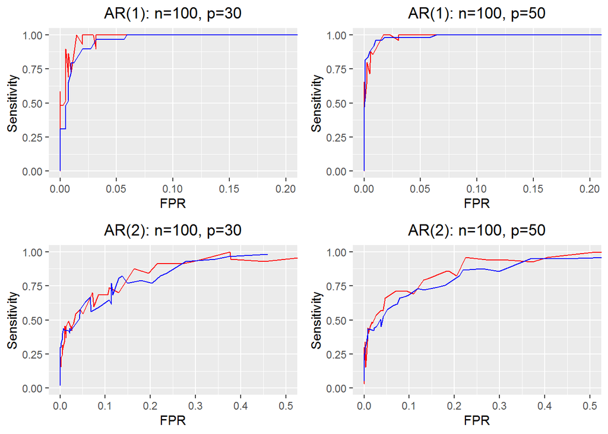

```r
#ROC curve

plot1=ggplot()+geom_line(mapping=aes(x=model1_samp1_roc[[1]],y=model1_samp1_roc[[2]]),color="red")+geom_line(mapping=aes(x=model1_sigma1_bayes_roc[[4]],y=model1_sigma1_bayes_roc[[2]]),color="blue")+labs(title="AR(1): n=100, p=30")+xlab("FPR")+ylab("Sensitivity")+theme(plot.title = element_text(hjust=0.5))+coord_cartesian(xlim=c(0,0.2),ylim=c(0,1))

plot2=ggplot()+geom_line(mapping=aes(x=model1_samp3_roc[[1]],y=model1_samp3_roc[[2]]),color="red")+geom_line(mapping=aes(x=model1_sigma2_bayes_roc[[4]],y=model1_sigma2_bayes_roc[[2]]),color="blue")+labs(title="AR(1): n=100, p=50")+xlab("FPR")+ylab("Sensitivity")+theme(plot.title = element_text(hjust=0.5))+coord_cartesian(xlim=c(0,0.2),ylim=c(0,1))

plot3=ggplot()+geom_line(mapping=aes(x=model2_samp1_roc[[1]],y=model2_samp1_roc[[2]]),color="red")+geom_line(mapping=aes(x=model2_sigma1_bayes_roc[[4]],y=model2_sigma1_bayes_roc[[2]]),color="blue")+labs(title="AR(2): n=100, p=30")+xlab("FPR")+ylab("Sensitivity")+theme(plot.title = element_text(hjust=0.5))+coord_cartesian(xlim=c(0,0.5),ylim=c(0,1))

plot4=ggplot()+geom_line(mapping=aes(x=model2_samp3_roc[[1]],y=model2_samp3_roc[[2]]),color="red")+geom_line(mapping=aes(x=model2_sigma2_bayes_roc[[4]],y=model2_sigma2_bayes_roc[[2]]),color="blue")+labs(title="AR(2): n=100, p=50")+xlab("FPR")+ylab("Sensitivity")+theme(plot.title = element_text(hjust=0.5))+coord_cartesian(xlim=c(0,0.5),ylim=c(0,1))

plot5=ggplot()+geom_line(mapping=aes(x=model3_samp1_roc[[1]],y=model3_samp1_roc[[2]]),color="red")+geom_line(mapping=aes(x=model3_sigma1_bayes_roc[[4]],y=model3_sigma1_bayes_roc[[2]]),color="blue")+labs(title="Star: n=100, p=30")+xlab("FPR")+ylab("Sensitivity")+theme(plot.title = element_text(hjust=0.5))+coord_cartesian(xlim=c(0,0.45),ylim=c(0,1))

plot6=ggplot()+geom_line(mapping=aes(x=model3_samp3_roc[[1]],y=model3_samp3_roc[[2]]),color="red")+geom_line(mapping=aes(x=model3_sigma2_bayes_roc[[4]],y=model3_sigma2_bayes_roc[[2]]),color="blue")+labs(title="Star: n=100, p=50")+xlab("FPR")+ylab("Sensitivity")+theme(plot.title = element_text(hjust=0.5))+coord_cartesian(xlim=c(0,0.45),ylim=c(0,1))

plot7=ggplot()+geom_line(mapping=aes(x=model4_samp1_roc[[1]],y=model4_samp1_roc[[2]]),color="red")+geom_line(mapping=aes(x=model4_sigma1_bayes_roc[[4]],y=model4_sigma1_bayes_roc[[2]]),color="blue")+labs(title="Circle: n=100, p=30")+xlab("FPR")+ylab("Sensitivity")+theme(plot.title = element_text(hjust=0.5))+coord_cartesian(xlim=c(0.15,0.4),ylim=c(0,1))

plot8=ggplot()+geom_line(mapping=aes(x=model4_samp3_roc[[1]],y=model4_samp3_roc[[2]]),color="red")+geom_line(mapping=aes(x=model4_sigma2_bayes_roc[[4]],y=model4_sigma2_bayes_roc[[2]]),color="blue")+labs(title="Circle: n=100, p=50")+xlab("FPR")+ylab("Sensitivity")+theme(plot.title = element_text(hjust=0.5))+coord_cartesian(xlim=c(0.15,0.4),ylim=c(0,1))

grid.arrange(plot1,plot2,plot3,plot4,ncol=2)
```

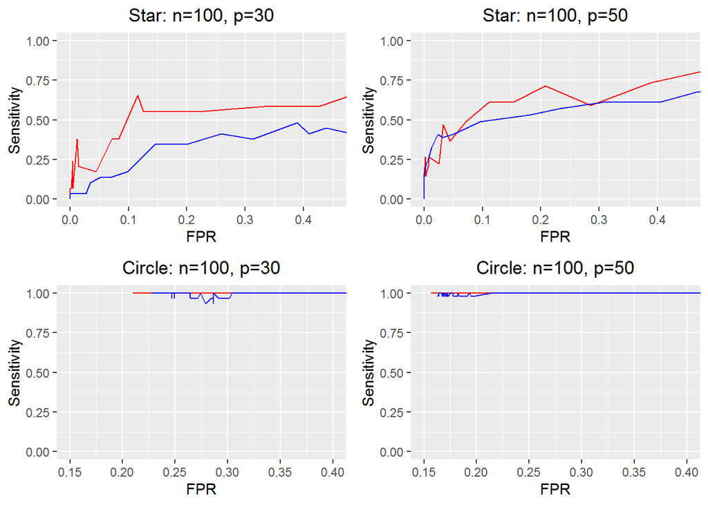

```r
grid.arrange(plot5,plot6,plot7,plot8,ncol=2)
```

```r
#Protein_data
protein_data=cytometryContinuous$data

#Sample covariance matrix from protein data
protein_data_var=var(protein_data)*7465/7466
```

```r
#true network edge

edge=matrix(NA,nrow=22,ncol=2)
edge[1,]=c(1,2)
edge[2,]=c(1,8)
edge[3,]=c(1,9)
edge[4,]=c(2,6)
edge[5,]=c(2,8)
edge[6,]=c(2,9)
edge[7,]=c(3,4)
edge[8,]=c(3,5)
edge[9,]=c(3,9)
edge[10,]=c(4,5)
edge[11,]=c(4,9)
edge[12,]=c(5,6)
edge[13,]=c(5,7)
edge[14,]=c(5,8)
edge[15,]=c(6,7)
edge[16,]=c(6,8)
edge[17,]=c(7,8)
edge[18,]=c(8,9)
edge[19,]=c(8,10)
edge[20,]=c(8,11)
edge[21,]=c(9,10)
edge[22,]=c(9,11)

edge_indicator=matrix(rep(0,11^2),ncol=11)
for(i in 1:22){
  edge_indicator[edge[i,1],edge[i,2]]=1
}
true_gamma=edge_indicator[upper.tri(edge_indicator)]

#frequentist GL
protein_gl_freq=glasso(protein_data_var,rho=0.4)$wi

#frequentist GL model indicator
freq_gamma=edge_count(protein_gl_freq)

#Bayesian GL
protein_gl_bayes=bayesian_GL_data(7466,11,protein_data_var,0.4,0.4,1,1,10000,2000)

#Bayesian GL model indicator
bayes_gamma=protein_gl_bayes[,,1]
```

By comparing estimated model indicators and true network(model indicator), we calculate performances and draw networks.

```r
#Performance

method=c("Freq","Bayes")
tp1=length(intersect(which(freq_gamma==1),which(true_gamma==1)))
tn1=length(intersect(which(freq_gamma==0),which(true_gamma==0)))
fp1=length(intersect(which(freq_gamma==1),which(true_gamma==0)))
fn1=length(intersect(which(freq_gamma==0),which(true_gamma==1)))
sp1=tn1/(tn1+fp1); se1=tp1/(tp1+fn1); mcc1=(tp1*tn1-fp1*fn1)/sqrt((tp1+fp1)*(tp1+fn1)*(tn1+fp1)*(tn1+fn1))

tp2=length(intersect(which(bayes_gamma==1),which(true_gamma==1)))
tn2=length(intersect(which(bayes_gamma==0),which(true_gamma==0)))
fp2=length(intersect(which(bayes_gamma==1),which(true_gamma==0)))
fn2=length(intersect(which(bayes_gamma==0),which(true_gamma==1)))
sp2=tn2/(tn2+fp2); se2=tp2/(tp2+fn2); mcc2=(tp2*tn2-fp2*fn2)/sqrt((tp2+fp2)*(tp2+fn2)*(tn2+fp2)*(tn2+fn2))

#table of performance
tibble(method=method,Specificity=c(sp1,sp2),Sensitivity=c(se1,se2),MCC=c(mcc1,mcc2))
```

```
## # A tibble: 2 x 4
##   method Specificity Sensitivity    MCC
##   <chr>        <dbl>       <dbl>  <dbl>
## 1 Freq         0.606       0.455 0.0602
## 2 Bayes        0.636       0.364 0
```

One can see that Bayesian GL shows better in specificity than frequentist GL. But, as we’re concentrating only on regular models by setting $q<\frac{1}{2}$, we’re allowing less edges in the model so that Bayesian GL suffers in sensitivity compared to frequentist GL.

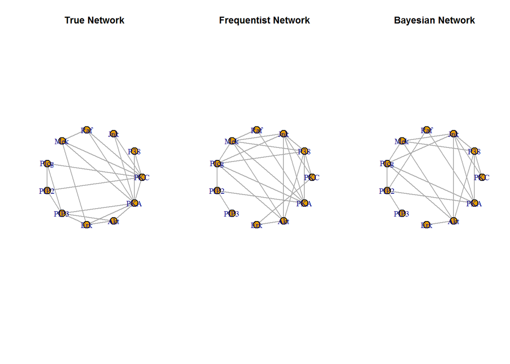

```r
#True network
protein_network=make_graph(c("Raf","Mek","Raf","PKA","Raf","PKC",                             "Mek","Erk","Mek","PKA","Mek","PKC",
                     "Plcg","PIP2","Plcg","PIP3","Plcg","PKC",
                     "PIP2","PIP3","PIP2","PKC",
                     "PIP3","Erk","PIP3","Akt","PIP3","PKA",
                     "Erk","Akt","Erk","PKA",
                     "Akt","PKA","PKA","PKC","PKA","P38",
                     "PKA","Jnk","PKC","P38","PKC","Jnk"),directed=FALSE)

#network by frequentist GL
freq_network=make_graph(c("Raf","Mek","Mek","Plcg","Plcg","PIP2",
                             "PIP2","PIP3","Mek","Akt","Plcg","Akt",
                             "Erk","Akt","Raf","PKA","Mek","PKA",
                             "Plcg","PKA","PIP2","PKA","Erk","PKC",
                             "Mek","P38","Plcg","P38","Akt","P38",
                             "PKA","P38","PKC","P38","Mek","Jnk",
                             "Plcg","Jnk","Akt","Jnk","PKA","Jnk",
                             "PKC","Jnk","P38","Jnk"),directed=FALSE)

#network by Bayesian GL
bayes_network=make_graph(c("Mek","Plcg","Raf","PIP2","Plcg","PIP2",
                           "PIP2","PIP3","Mek","Akt","Plcg","Akt",
                           "Erk","Akt","Raf","PKA","Plcg","PKA",
                           "PIP2","PKA","Mek","P38","Akt","P38",
                           "PKA","P38","PKC","P38","Mek","Jnk",
                           "Plcg","Jnk","Akt","Jnk","PKA","Jnk",
                           "PKC","Jnk","P38","Jnk"),directed=FALSE)


layout1=layout_in_circle(protein_network,order=c("PKC","P38","Jnk","Raf","Mek","Plcg","PIP2","PIP3","Erk","Akt","PKA"))

layout2=layout_in_circle(freq_network,order=c("PKC","P38","Jnk","Raf","Mek","Plcg","PIP2","PIP3","Erk","Akt","PKA"))

layout3=layout_in_circle(bayes_network,order=c("PKC","P38","Jnk","Raf","Mek","Plcg","PIP2","PIP3","Erk","Akt","PKA"))

par(mfrow=c(1,3))

plot(protein_network,layout=layout1,edge.size=2,main="True Network")
plot(freq_network,layout=layout2,edge.size=2,main="Frequentist Network")
plot(bayes_network,layout=layout3,edge.size=2,main="Bayesian Network")
```

From the grpahs above, the model estimated by Bayesian GL shows less edges, hence suffers in sensitivity. However, one cannot say frequentist GL performs good in that specificity is low and more edges are connected to Jnk, AKt in the model estimated by frequentist GL than true network.